# Análisis de datos ambientales

# Series temporales Representando la Magnitud 14 - Datos brutos diarios

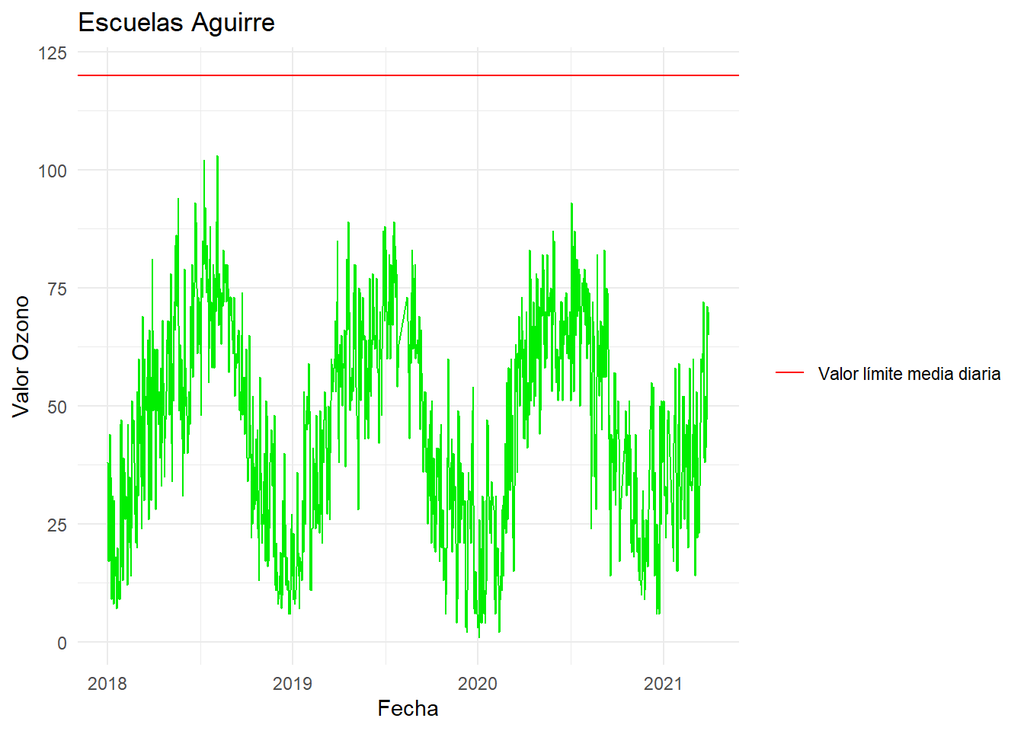

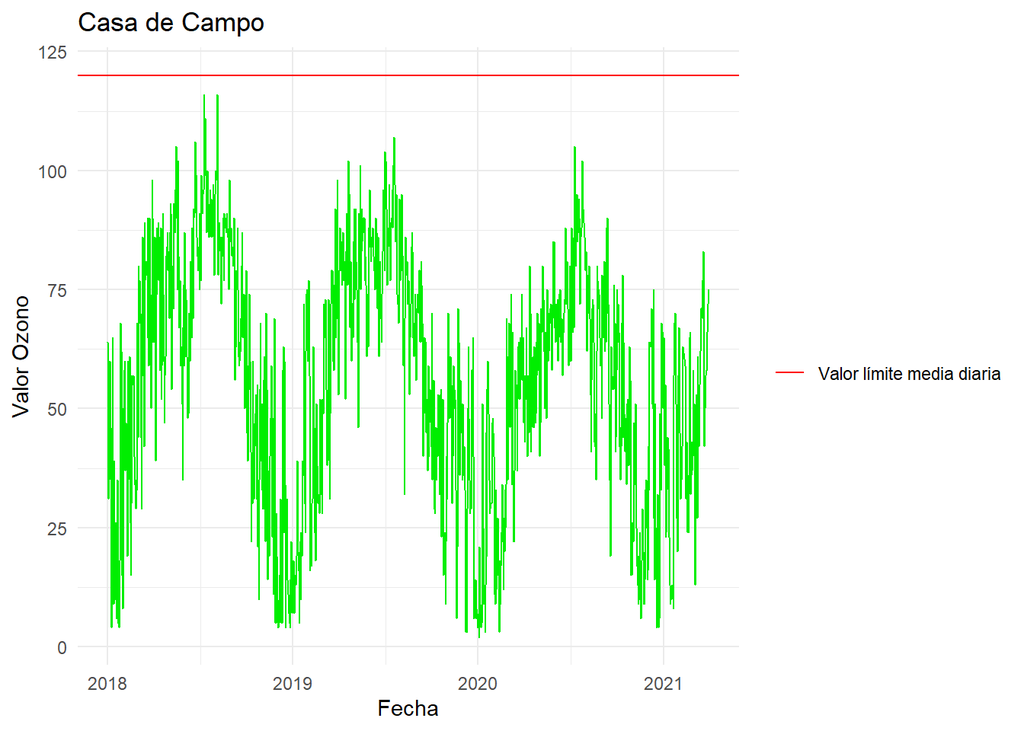

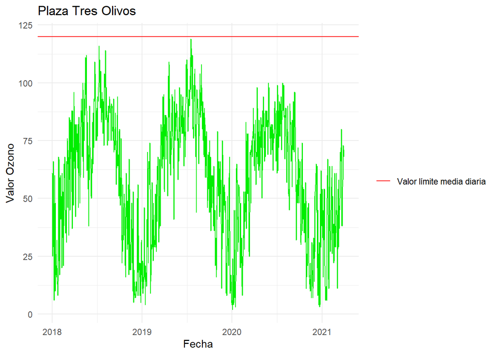

```r
for (punto in puntos){
muestra_mag14 <- df%>% filter(nombre_estacion==punto & magnitud==14)


plot_14 <- ggplot(muestra_mag14, aes(x=fecha, y=valor)) +
  geom_line(color="green2")+ theme_minimal()+ ggtitle(punto)+
   geom_hline(aes(yintercept=120, color="Valor límite media diaria"))+
  scale_colour_manual(values = c("red"))+labs(color="")+
  xlab("Fecha")+ylab("Valor Ozono")
print(plot_14)

}
```

# Descomposición de serie temporal mensual para la estación 8, Escuelas Aguirre.

Esta estación se encuentra ubicada entre Calle Alcalá y C/O’Donell. Se trata de una estación de tipo “Urbana tráfico”. Hemos representado sus respectivos parámetros que son Dióxido de nitrógeno (8), Partículas <2.5um (9), Particulas <10um (10), Ozono (14).

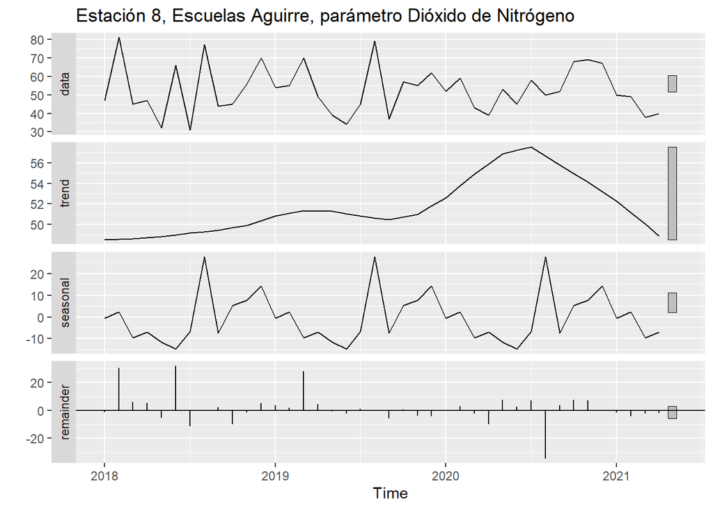

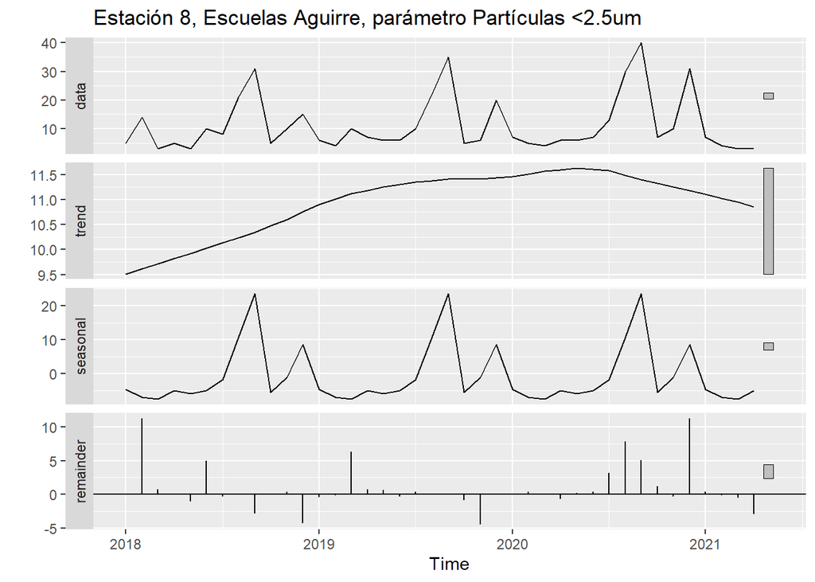

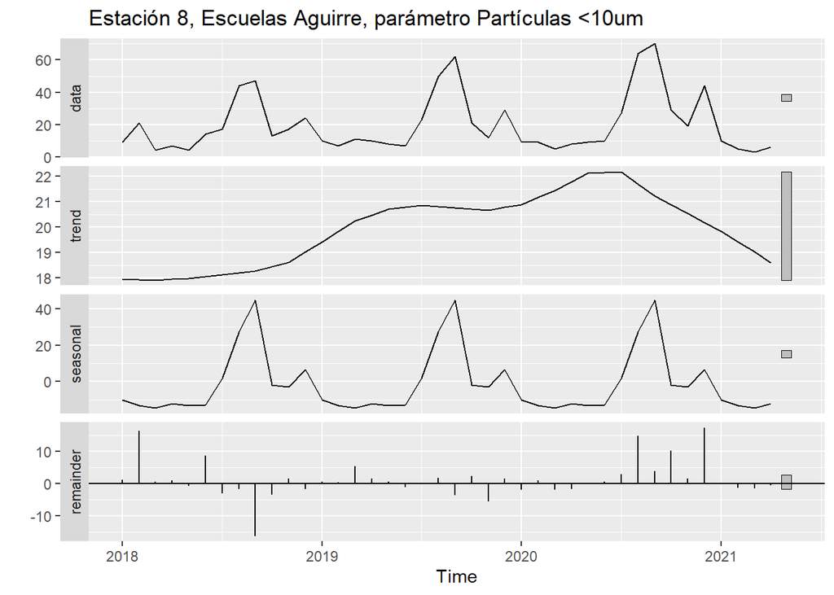

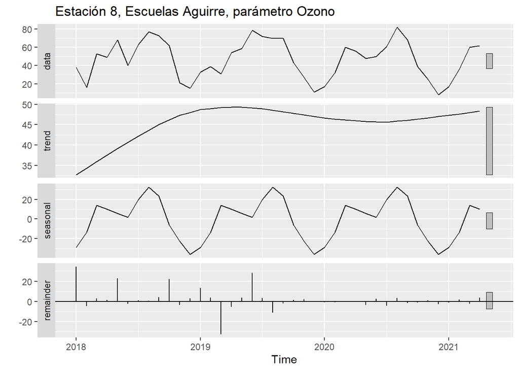

# Descomposición de serie temporal mensual para la estación 24, Casa Campo.

Se trata de una estación de tipo “Suburbana”. Hemos representado sus respectivos parámetros que son Dióxido de nitrógeno (8), Partículas <2.5um (9), Partículas <10um (10), Ozono (14).

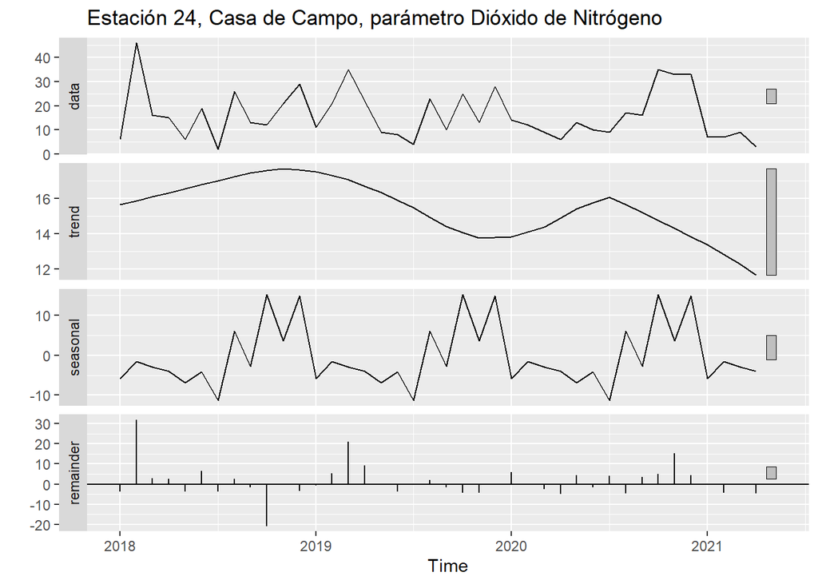

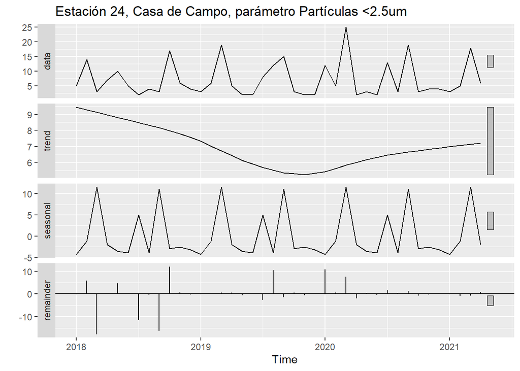

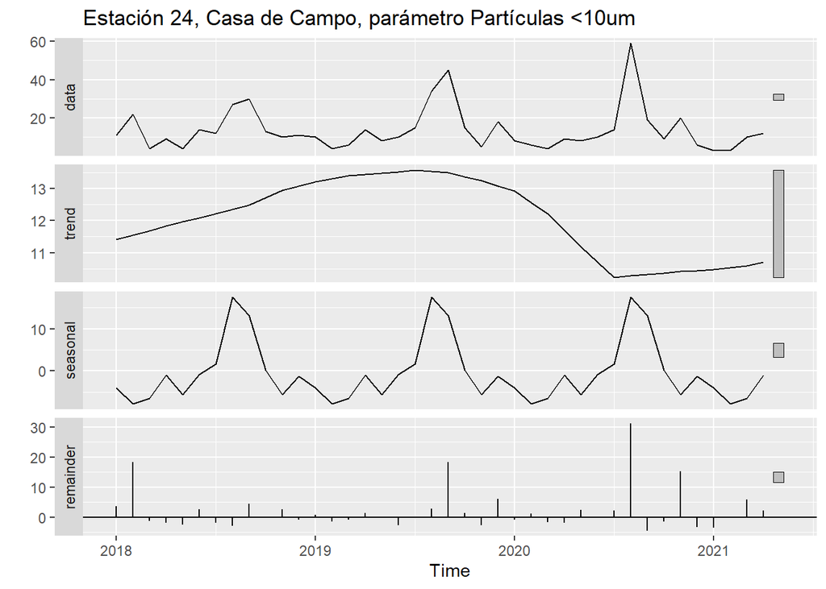

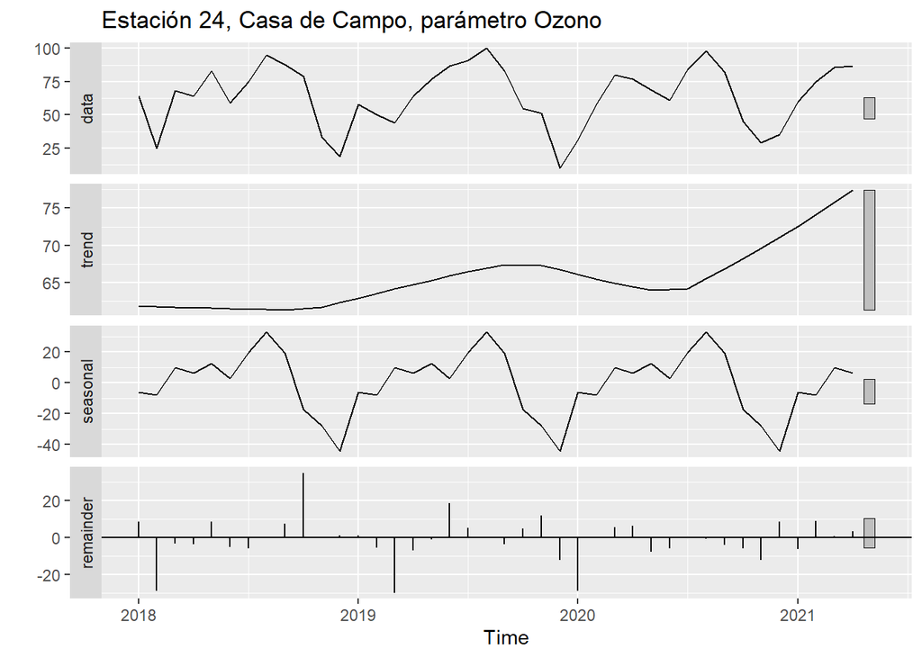